# 자연언어처리 5주차_텍스트 마이닝을 사용한 자연언어처리 #3: 토픽 모델링

고려대학교 일반대학원 심리학과

2022년 10월 3일 월요일 6-7교시

# 1. tidy 텍스트 형식 다루기

[4주차 수업자료](http://cognitivepsychology.github.io/NLP/week4.html) 참조.

# 2. tidy 텍스트로 감성분석(sentiment analysis) 수행하기

[4주차 수업자료](http://cognitivepsychology.github.io/NLP/week4.html) 참조.

# 3. tidy 텍스트로 토픽 모델링(topic modelling) 수행하기

- 토픽 모델링 소개
  - 방대한 문서 데이터에서 주제(topics)를 탐색하는 통계적 모형.
  - 문서들을 비지도(unsupervised) 분류하는 방법 중 하나.
  - 문서를 집단별로 묶어내는 방법([EX] 군집분석[cluster analysis]). 이에 따르면 각 문서는 하나의 집단에만 속함.
- LDA(latent Dirichlet allocation) 소개
  - 토픽 모델(topic model)을 적합화하는 데 널리 사용되는 방법 중 하나.
  - 각 문서를 주제들(topics)의 집합 & 각 주제를 단어들의 집합으로 간주.
  - 실제로 내용 면에서 문서들은 서로 일정 부분 서로 겹치게 됨. 즉 각 문서는 하나 이상을 주제를 가지고 있음.

## (1) 잠재 디리클레 할당(latent Dirichlet allocation, LDA)

### 1) 원리와 특징

- 제창자: 19세기 독일 수학자 러죈 디리클레(Lejeune Dirichlet, 1805-1859). 그가 제안한 디리클레 분포(Dirichlet distribution)를 이용해 문서에 잠재된 주제를 추론.
- 원리
  - **모든 문서는 주제들이 무작위로 섞인 임의의 혼합물(mixture)이다**
    - 각 문서는 여러 주제의 단어들을 특정한 비율로 포함하고 있다고 가정.
    - [EX] 2-주제 모형의 경우, “문서 1은 주제 A가 90퍼센트 & 주제 B가 10퍼센트인 반면, 문서 2는 주제 A가 30퍼센트 & 주제 B가 70퍼센트이다”라고 말할 수 있음.
  - **모든 주제는 단어들이 무작위로 섞인 임의의 혼합물이다**
    - [EX] 한국 뉴스에 대한 2-주제 모형
      - “정치”와 “연예”로 구분됨. 정치 주제에서 가장 자주 나타나는 단어는 “대통령,”의회”, “정부”.
      - 연예 주제에서 가장 자주 나타나는 단어는 “영화”, “TV”, “배우”.
      - “예산”은 두 주제에서 비슷한 빈도로 나타날 것.
- 특징
  - LDA는 두 원리를 모두 고려하여 추정해주는 수학적 방법: 각 주제와 연관된 단어들을 찾는 동시에 각 문서를 설명해주는 주제들을 판단함.
  - 해당 알고리즘을 수행하는 다양한 방법들이 존재. 그러나 본 수업에서는 그중 하나를 집중적으로 고찰.
  - LDA에서 정의하는 주제: 주제 = 특정 단어들의 분포. [EX] 주제가 경제학이라면, 해당 주제일 때 높은 확률로 분포하는 단어들을 통해 특정 문서의 주제가 경제학인지 여부를 판단함.
- 수행과정
  1. 사용자가 알고리즘에게 초매개변수(hyperparameter)인 주제의 개수 *k* 알려주기: LDA는 주제의 개수 *k*를 입력받으면, *k*개의 주제가 *M*개의 문서에 걸쳐 분포한다고 가정.
  2. 모든 단어를 *k*개의 주제 중 하나에 할당: 모든 문서의 모든 단어에 대해 *k*개 중 하나의 주제를 무작위로 할당(최적의 개수 *k*는 사용자가 수차례 실험을 통해 찾아야 하는 미지수임). $\rightarrow$ 각 문서는 고유의 주제를 지니며, 주제마다 단어들의 분포가 생성됨. 하지만 무작위로 할당했으므로 당연히 틀린 결과일 것.
  3. 모든 문서의 모든 단어에 대해 아래 과정 반복
     - LDA의 기본가정: 단어별로 주제를 할당할 때 어떤 문서의 특정 단어 *w*는 잘못된 주제를 할당받았을지라도, 다른 단어들은 모두 올바른 주제에 할당되어 있다고 가정함.
     - 단어별 주제 재할당 기준
       - $p(주제\; t\;|\;문서\;d)$: 문서 *d*에 속한 단어들 중 주제 *t*에 해당하는 단어의 비율.
       - $p(단어\; w\;|\;주제\;t)$: 단어 *w*를 지닌 모든 문서 중 주제 *t*에 할당된 문서의 비율.
     - 위의 재할당 과정을 반복함으로써 모든 단어에 대한 주제할당은 수렴상태에 이르게 됨.

**[그림 2] *d* 번째 문서에 있는 *i* 번째 단어의 주제 $z_d,_i$가 *j* 번째에 할당될 확률**

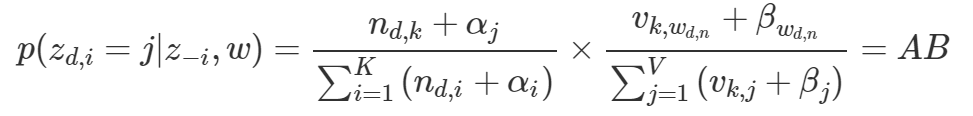

**[그림 3] 위 수식에 사용된 변수 설명**

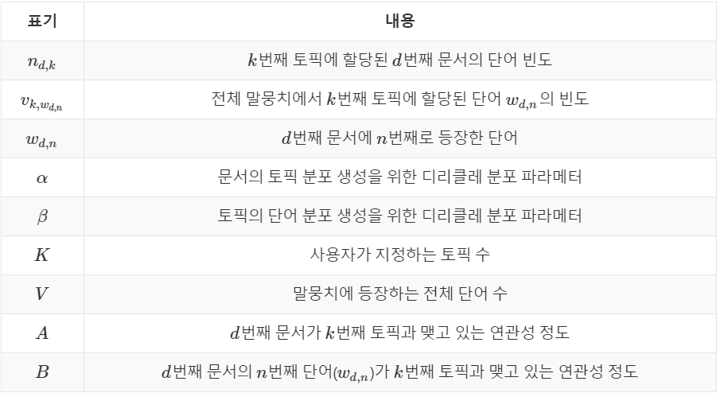

**[그림 4] LDA 수행 흐름도 예시(Blei, 2012)**

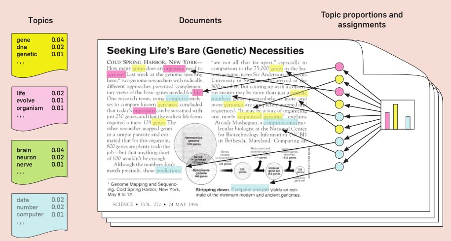

- **[그림 4]** 설명
  - 분석대상 논문: “Seeking life’s bare (genetics) necessities.”
  - 색상별 주제
    - 노란색: 유전학.
    - 분홍색: 진화생물학.
    - 파란색: 자료분석.
  - 맨 왼쪽: 주제별 단어확률 분포
  - 맨 오른쪽 히스토그램: 주제별 단어분포 할당.
  - 색깔 동그라미: 단어별 주제분포 할당.
  - 화살표: 해당 주제를 구성하는 단어 선택.

### 2) 문서-용어 매트릭스(document-term matrix, DTM)

#### A. 소개

- 설명
  - **topicmodels**를 비롯한 대부분의 텍스트 마이닝 패키지가 선호하는 데이터 구조.
  - 특징
    - 각 행은 하나의 문서([EX] 책, 기사, 소설, 논문 등)를 나타냄.
    - 각 열은 하나의 용어(term)를 나타냄.
    - 각 값은 대체로 문서에 용어가 나타난 횟수를 가리킴.
    - 그러나 대부분의 문서-단어 쌍은 빈도가 0에 수렴함. [EX] 연예 주제에서도 “필립 세이무어 호프먼”이라는 용어가 나타난 문서는 매우 희귀할 것.
  - DTM $\leftrightarrow$ tidy 형식 간 변환
    - DTM은 **tidyverse** 패키지를 곧바로 적용할 수 없음.
    - DTM과 tidy 데이터프레임 간 변환을 제공하는 **tidytext** 패키지 함수
      - `tidy()`: DTM을 tidy 데이터프레임으로 변환해줌. **broom** 패키지에서 제공.
      - `cast()`: tidy 데이터프레임을 다른 데이터 마이닝 패키지 매트릭스 형식으로 변환해줌.
        - `cast_sparse()`: **Matrix** 패키지의 매트릭스로 변환해줌.
        - `cast_dtm()`: **tm** 패키지의 `DocumentTermMatrix` 객체로 변환해줌.
        - `case_dfm()`: **quanteda** 패키지의 `dfm` 객체로 변환해줌.
- **tm** 패키지의 `DocumentTermMatrix` 객체 예시
  - `VCorpus`: R 내부에서 생성된 말뭉치.
  - `VectorSource`: 문자열 벡터. 각 문자열을 하나의 문서로 취급.
  - `DocumentTermMatrix`: corpus를 DTM으로 만들어주는 함수.
    - term의 수: 모든 문서에 존재하는 단어의 총 개수. [EX] 2개 문서(문자열)에 총 4개의 term 존재.
    - sparcity: 하나의 문서에만 출현하는 term의 수. [EX] 25% $\rightarrow$ 8개 term(4개 term * 2개 문서) 중 2개.

```r
# tm 패키지로 DTM 생성하는 방법.
library(tidyverse)
library(tidytext)
library(tm)
text <- c("바나나는 꼭지가 있어요", "바나나는 껍질이 있어요")
my_tm_corpus <- VCorpus(VectorSource(text)) # text 벡터를 문자열 벡터 말뭉치로 변환해줌.
dtm <- DocumentTermMatrix(my_tm_corpus) # my_tm_corpus를 DTM으로 만들어줌.
dtm
```

```
## <<DocumentTermMatrix (documents: 2, terms: 4)>>
## Non-/sparse entries: 6/2
## Sparsity           : 25%
## Maximal term length: 4
## Weighting          : term frequency (tf)
```

```r
inspect(dtm) # inspect 함수로 DocumentTermMatrix 객체의 구조와 요약정보 확인.
```

```
## <<DocumentTermMatrix (documents: 2, terms: 4)>>
## Non-/sparse entries: 6/2
## Sparsity           : 25%
## Maximal term length: 4
## Weighting          : term frequency (tf)
## Sample             :
##     Terms
## Docs 껍질이 꼭지가 바나나는 있어요
##    1      0      1        1      1
##    2      1      0        1      1
```

#### B. 예시

- **tm** 패키지를 활용하여 DTM 객체 생성하기
  - **topicmodels**는 DTM 객체를 바탕으로 분석을 시행.
  - **tm**의 `DocumentTermMatrix` 주요 논항
    - `x` = tm의 Corpus 객체.
    - `control = list()`
      - `stopwords`: 불용어 제거 여부. 선택지 = `TRUE` 또는 `FALSE`.
      - `minWordLength`: 최소 단어 길이 = 숫자.
      - `removeNumbers`: 숫자 제거 여부. 선택지 = `TRUE` 또는 `FALSE`.
      - `removePunctuation`: 구두점 제거 여부. = `TRUE` 또는 `FALSE`.

> DocumentTermMatrix(x = my_tm_corpus, control = list(stopwords = T, minWordLength = 2, removeNumbers = T, removePunctuation = T))
- AI Hub가 제공하는 논문요약(초록) JSON 데이터 중 사회과학-경제 분야 초록 추출하기

```r
# jsonlite 패키지 불러오기.
library(jsonlite)

# 단일 json 파일 데이터 프레임으로 불러들이기.
article.json <- fromJSON("texts/topicmodels/논문요약_0206_0.json", simplifyDataFrame =T)

# 데이터의 구조 살펴보기.
attributes(article.json)
```

```
## $names
## [1] "totalcount" "data"
```

```r
# data 섹션만 추출하여 티블 형식으로 변환하기.
article.2 <- article.json$data %>%
  as_tibble()
article.2
```

```
## # A tibble: 32,000 x 10
##    doc_type doc_id      title date  reg_no ipc   issued_by author summary_entire
##    <chr>    <chr>       <chr> <chr> <chr>  <chr> <chr>     <chr>  <list>
##  1 논문     A201008176~ 교직~ 2018  ART00~ 사회~ 사범대학~ 조석~  <df [1 x 2]>
##  2 논문     A201008176~ 평면~ 2018  ART00~ 사회~ 사범대학~ 정영~  <df [1 x 2]>
##  3 논문     A201008176~ 한국~ 2018  ART00~ 사회~ 사범대학~ 양림 ~ <df [1 x 2]>
##  4 논문     A201008176~ 로봇~ 2018  ART00~ 사회~ 한국교육~ 노지~  <df [1 x 2]>
##  5 논문     A201008176~ 고등~ 2018  ART00~ 사회~ 사범대학~ 김창~  <df [1 x 2]>
##  6 논문     A201008176~ 창의~ 2018  ART00~ 사회~ 한국교육~ 박태~  <df [1 x 2]>
##  7 논문     A201008176~ 자아~ 2018  ART00~ 사회~ 한국건강~ 김시~  <df [1 x 2]>
##  8 논문     A201008176~ 침습~ 2018  ART00~ 사회~ 한국건강~ 고은~  <df [1 x 2]>
##  9 논문     A201008176~ 한국~ 2018  ART00~ 사회~ 사범대학~ 김원~  <df [1 x 2]>
## 10 논문     A201008176~ 컴퓨~ 2018  ART00~ 사회~ 한국교육~ 나청~  <df [1 x 2]>
## # ... with 31,990 more rows, and 1 more variable: summary_section <list>
```

```r
# for문을 사용하여 summary_entire의 original_text 섹션만 추출하기.
article.3 <- list()
for(i in 1:nrow(article.2)){
  article.3[[i]] <- map_dfr(article.2$summary_entire[[i]][1], function(x) as_tibble(x))
}

# 리스트 형식으로 추출된 결과물을 티블 형식으로 변환하기.
article.3.1 <- map_dfr(article.3, function(x) as_tibble(x)) %>%
  rename(summary = value) # 열 이름 summary로 바꾸기.
article.3.1
```

```
## # A tibble: 32,000 x 1
##    summary
##    <chr>
##  1 본 연구는 경제협력개발기구(Organization for Economic Cooperation and Develop~
##  2 학교수학에서 다루어지는 테셀레이션에 관한 내용은 주로 기하학적 관점의 결과론~
##  3 본 연구는 박근혜 정부에서 추진되었던 한국사교과서 국정화에 대한 정책변동에 ~
##  4 컴퓨팅사고력은 컴퓨팅의 기본적인 개념과 원리를 기반으로 문제를 효율적으로 해~
##  5 본 연구는 고등학생들의 바른 인성함양을 위한 긍정적 태도 형성 프로그램의 효과~
##  6 새로 도입된 피지컬컴퓨팅 교육을 통해 학생들이 창의적으로 문제를 해결하거나 ~
##  7 본 연구에서는 자아고갈 상태에서 냉압과제 수행동기가 통증반응(인내, 강도, 불~
##  8 본 연구는 외상 후 성장 이론을 바탕으로 침습적 반추, 정서조절방략 그리고 의도~
##  9 본 연구는 학교폭력 가해행동 관련변인을 메타분석을 이용해 체계적으로종합하고 ~
## 10 본 연구의 목적은 컴퓨팅 사고력 향상을 위한 SW 교육의 효과성을 메타분석을 통~
## # ... with 31,990 more rows
```

```r
# doc_type:author 열(총 8개 열) 옆에 summary 열 부착한 뒤, 분석에 불필요한 summary_entire와 summary_section 열 제거하기.
article.4 <- bind_cols(article.2, article.3.1) %>%
  select(-summary_entire, -summary_section)
article.4
```

```
## # A tibble: 32,000 x 9
##    doc_type doc_id        title      date  reg_no ipc   issued_by author summary
##    <chr>    <chr>         <chr>      <chr> <chr>  <chr> <chr>     <chr>  <chr>
##  1 논문     A201008176694 교직 선택~ 2018  ART00~ 사회~ 사범대학~ 조석~  본 연~
##  2 논문     A201008176695 평면 테셀~ 2018  ART00~ 사회~ 사범대학~ 정영~  학교수~
##  3 논문     A201008176696 한국사교~  2018  ART00~ 사회~ 사범대학~ 양림 ~ 본 연~
##  4 논문     A201008176697 로봇 활용~ 2018  ART00~ 사회~ 한국교육~ 노지~  컴퓨팅~
##  5 논문     A201008176698 고등학생~  2018  ART00~ 사회~ 사범대학~ 김창~  본 연~
##  6 논문     A201008176699 창의적 문~ 2018  ART00~ 사회~ 한국교육~ 박태~  새로 ~
##  7 논문     A201008176700 자아고갈 ~ 2018  ART00~ 사회~ 한국건강~ 김시~  본 연~
##  8 논문     A201008176701 침습적 반~ 2018  ART00~ 사회~ 한국건강~ 고은~  본 연~
##  9 논문     A201008176702 한국 청소~ 2018  ART00~ 사회~ 사범대학~ 김원~  본 연~
## 10 논문     A201008176703 컴퓨팅 사~ 2018  ART00~ 사회~ 한국교육~ 나청~  본 연~
## # ... with 31,990 more rows
```

```r
# 사회과학-경제 관련 학회 출판 논문 초록 추출하기.
article.biz <- article.4 %>%
  filter(ipc == "사회과학" & str_detect(issued_by, "경영|경제|무역|마케팅|회계|기업|금융|생산|산업")) %>%
  mutate(field = "경제") %>%
  select(2, 9) %>% # doc_id와 summary 열 추출하기.
  rename(text = summary) # tm의 DataframeSource는 열 이름이 doc_id와 text여야 하므로 열 이름 바꿔주기.
article.biz
```

```
## # A tibble: 2,226 x 2
##    doc_id        text
##    <chr>         <chr>
##  1 A201008176863 본 연구는 정부의 신협 관련 정책을 검토하고 그 성과를 분석한다.~
##  2 A201008176891 이 연구에서는 상황적 접근(Contingency approach)를 통해, 제휴 ~
##  3 A201008176910 항공기제조분야에서 후발국가인 한국은 2003년 초음속 군사용 항공~
##  4 A201008176974 특허 심사 청구 제도의 취지와 달리 기업들이 낮은 가치를 지닌 출~
##  5 A201008176986 본 연구의 목적은 다변화하는 사회적기업의 환경 속에서 그동안 한~
##  6 A201008177010 본 연구는 금융위기 이후 파생상품 시장의 과도한 레버리지로 인한~
##  7 A201008177018 본 연구에서는 우리나라 의료기기 제조기업 중 실제 연구개발을 통~
##  8 A201008177027 본 연구는 비영리조직인 병원의 고객지향성과 사회적 책임 활동이 ~
##  9 A201008177043 이 연구는 결혼이주여성 배우자의 문화적응스트레스와 가족건강성~
## 10 A201008177058 본 논문에서는 증권사 구분에 따라 증권분석가의 투자의견 중 투자~
## # ... with 2,216 more rows
```

- 추출된 논문초록 데이터 정규화하기

```r
# 형태소 분석 패키지 RcppMeCab 불러오기.
library(RcppMeCab)

# pos 함수로 논문초록 텍스트 토큰화하기.
article.biz.mecab <- article.biz %>%
  unnest_tokens(word, text, token = pos, drop = F) %>%
  filter(str_detect(word, "/nng|/nnp"),
         str_length(word) > 1) %>%
  separate(word, into = c("word", "pos"), sep = "/") %>%
  group_by(doc_id) %>%
  summarise(text = str_flatten(word, " ")) %>%
  ungroup()
article.biz.mecab
```

```
## # A tibble: 2,226 x 2
##    doc_id        text
##    <chr>         <chr>
##  1 A201008176863 연구 정부 신협 관련 정책 검토 성과 분석 정부 신협 신협 법 제정~
##  2 A201008176891 연구 상황 접근 제휴 포트폴리오 다양 조직 탐색 행동 양손잡이 전~
##  3 A201008176910 항공기 제조 분야 후발 국가 한국 초음속 군사 항공기 고등 훈련기~
##  4 A201008176974 특허 심사 청구 제도 취지 기업 가치 출원 특허 심사 의도 연기 가~
##  5 A201008176986 연구 목적 다변 사회 기업 환경 속 그동안 한국 사회 기업 연구 경~
##  6 A201008177010 연구 금융 위기 이후 파생 상품 시장 과도 레버리지 투기 폐해 정~
##  7 A201008177018 연구 나라 의료 기기 제조 기업 실제 연구 개발 특허 출원 등록 기~
##  8 A201008177027 연구 영리 조직 병원 고객 지향 사회 책임 활동 조직 평판 영향 실~
##  9 A201008177043 연구 결혼 주 여성 배우자 문화 스트레스 가족 건강 관계 사회 지~
## 10 A201008177058 논문 증권사 구분 증권 분석가 투자 의견 투자 등급 변경 상향 하~
## # ... with 2,216 more rows
```

- **tm**을 사용하여 DTM 객체 생성하기
  - `VCorpus`: R을 사용하여 직접 말뭉치를 제작하는 경우 사용되는 함수.
  - `DataframeSource`
    - `getSources()`: 데이터의 출처 유형 탐색하기.
    - 데이터프레임(티블) 형식이므로 `DataframeSource` 선택.
  - `DocumentTermMatrix`: DTM 객체로 만들어주는 함수.

```r
# tm 말뭉치 생성하기.
abstract_corpus <- VCorpus(DataframeSource(article.biz.mecab))

# 말뭉치를 DocumentTermMatrix 객체로 만들기.
abstract_corpus.dtm <- DocumentTermMatrix(abstract_corpus)
inspect(abstract_corpus.dtm)
```

```
## <<DocumentTermMatrix (documents: 2226, terms: 3134)>>
## Non-/sparse entries: 14769/6961515
## Sparsity           : 100%
## Maximal term length: 8
## Weighting          : term frequency (tf)
## Sample             :
##                Terms
## Docs            경영자 마케팅 브랜드 서비스 소비자 시사점 시스템 중소기업
##   A201008181028      0      0      0      8      0      0     10        0
##   A201008182434      0      0      0      1      0      2     16        0
##   A201008186701      0      2      5      0      0      1      0        0
##   A201008187197      0      0      0      0      0      0      0        0
##   A201008187972      0      1      0      1      0      1      0        0
##   A201008187987      0      0      0      0      1      0      0        0
##   A201008199334      0      0      0     22      0      1      0        0
##   A201008199335      0      4      0     10      7      1      0        0
##   A201008203872      0      1      0      7      0      0      0        0
##   A201008207606      0      2     14      1     20      1      0        0
##                Terms
## Docs            투자자 항공사
##   A201008181028      0      0
##   A201008182434      0      0
##   A201008186701      0     15
##   A201008187197      0      0
##   A201008187972      0      0
##   A201008187987      0      0
##   A201008199334      0      0
##   A201008199335      0      0
##   A201008203872      0      0
##   A201008207606      0      0
```

### 3) **topicmodels** 패키지의 `LDA` 함수로 LDA 모형 생성하기

#### A. `LDA` 함수의 주요 논항

- `x`: `DocumentTermMatrix` 객체.
- `k`: 사용자가 지정하는 주제의 수.
- `method`: 모형추정 방법. 선택지는 `VEM(variational expectation-maximization)`또는 `Gibbs`. `VEM`이 기본값임.
- `control = list()`: 모형추정을 위한 통제용 매개변수 리스트.
  - `alpha`(α): 문서의 주제 분포 생성을 위한 디리클레 분포 초매개변수에 해당. 시작 값은 주로 50/k로 잡음. 1에 가까워질수록 문서에 많은 주제 포함.
  - `beta`(β): 주제의 단어 분포 생성을 위한 디리클레 분포 초매개변수(논항으로 투입되지는 않음)에 해당. 1에 가까워질수록 주제에 많은 단어 포함.
  - `estimate.alpha`: `alpha`를 추정할 것인지 여부. 선택지 = `TRUE` 또는 `FALSE`.
  - `estimate.beta`: `beta`를 추정할 것인지 여부. 선택지 = `TRUE` 또는 `FALSE`.
  - `seed`: 난수생성을 위한 seed를 고정하는 경우. `Sys.time()` 함수를 사용하면 현재 시각에 맞추어 난수가 생성되므로 재현(reproductability) 불가.
  - `nstart`: 무작위 초기화(initialization)를 위한 반복수행 횟수.
  - `best`: 선택지 = `TRUE` 또는 `FALSE`. `best = TRUE`이면 로그-우도(log-likelihood) 값에 비추었을 때 최상의 모형만 반환해줌.
  - `initialize`: 주제들이 최화되는 방식 결정. 선택지 = `random`, `seeded`, `model`.
    - `random`: 무작위 초기화는 각 주제가 무작위로 초기화되는 것.
    - `seeded`: seed 설정 초기화는 각 주제가 무작위로 선택된 문서에 바탕을 둔 분포에 따라 초기화되는 것.
    - `model`: 기존의 적합화(fitting)에 사용된 모형이 제공되어야 함. 기존 모형을 따로 제공하지 않는 경우 무작위 초기화가 기본값임.

> LDA(x, k, method = “VEM”, control = list(estimate.alpha = TRUE, alpha = 50/k, estimate.beta = TRUE, seed = as.integer(Sys.time()), nstart = 1, best = TRUE, initialize = “random”))

#### B. LDA 실행하기

##### 가. `LDA` 함수로 LDA 실행하기

- `LDA` 함수로 2-주제 LDA 모형 생성하기: 물론 실제로 주제의 수 `k`는 2보다 더 클 것. 그러나 현재는 시험 삼아 `k`를 2로 설정함.

```r
library(topicmodels)

# 2-주제 LDA 모형 생성하기.
abstract_lda <- LDA(abstract_corpus.dtm, k = 2, control = list(seed = 1234)) # seed를 고정하면 다음에도 똑같은 결과를 재현할 수 있음.
```

```r
library(topicmodels)

# 오류가 발생할 경우: 모든 단어의 빈도가 0인 행 제거.
ui <- unique(abstract_corpus.dtm$i)
abstract_corpus.dtm.1 <- abstract_corpus.dtm[ui,]

# 2-주제 LDA 모형 재생성하기.
abstract_lda <- LDA(abstract_corpus.dtm.1, k = 2, control = list(seed = 1234)) # seed를 고정하면 다음에도 똑같은 결과를 재현할 수 있음.
abstract_lda
```

```
## A LDA_VEM topic model with 2 topics.
```

##### 나. 단어-주제 확률

- `tidy` 함수: 통계모형 객체(여기서는 LDA 객체)를 tidy 형식으로 바꿔주는 **broom** 패키지 유래 함수.
- β
  - 특정 단어가 특정 주제에 할당될 확률: “모든 주제는 단어들이 무작위로 섞인 임의의 혼합물이다.”
  - `matrix` = “beta”를 지정해주면 주제, 단어, β 값이 제시됨.

```r
abstract_topics <- tidy(abstract_lda, matrix = "beta")
abstract_topics
```

```
## # A tibble: 6,268 x 3
##    topic term         beta
##    <int> <chr>       <dbl>
##  1     1 가격대   6.14e- 5
##  2     2 가격대   1.32e- 4
##  3     1 가격정책 6.14e- 5
##  4     2 가격정책 9.07e-12
##  5     1 가격제   2.62e-58
##  6     2 가격제   1.19e- 3
##  7     1 가계부   4.91e- 4
##  8     2 가계부   8.09e-63
##  9     1 가계조사 1.32e- 6
## 10     2 가계조사 1.97e- 4
## # ... with 6,258 more rows
```

- 결과해석
  - LDA 모형을 하나의 행에 하나의 주제와 단어가 들어 있는 형식으로 변환함.
  - 각 주제-단어 조합에 대해 해당 주제로부터 특정 단어가 생성될 확률(β)을 계산함.
  - 해석: “가격대”가 주제 1로부터 생성될 확률은 $6.14 \times10^{-5}$이지만, 주제 2로부터 생성될 확률은 $1.32 \times10^{-4}$임.
- 각 주제에서 가장 자주 등장하는 단어 10개 확인하기
  - 티블: `slice_max` 함수 사용.
  - 시각화: **ggplot2** 패키지 사용.

```r
# 주제별 최빈 단어 10개 확인하기: 티블 버전.
abs_top_terms <- abstract_topics %>%
  group_by(topic) %>% # 주제별로 grouping하기.
  slice_max(beta, n = 10) %>% # 상위빈도 10개 단어만 서브세팅.
  ungroup() %>% # grouping 풀기.
  arrange(topic, -beta) # 주제 오름차순, 베타 내림차순으로 배열하기.
abs_top_terms
```

```
## # A tibble: 20 x 3
##    topic term       beta
##    <int> <chr>     <dbl>
##  1     1 서비스   0.0728
##  2     1 소비자   0.0413
##  3     1 브랜드   0.0350
##  4     1 시사점   0.0210
##  5     1 시스템   0.0196
##  6     1 마케팅   0.0190
##  7     1 구성원   0.0177
##  8     1 리더십   0.0163
##  9     1 프로그램 0.0135
## 10     1 경쟁력   0.0126
## 11     2 경영자   0.0388
## 12     2 중소기업 0.0309
## 13     2 항공사   0.0219
## 14     2 투자자   0.0199
## 15     2 외국인   0.0192
## 16     2 시스템   0.0154
## 17     2 비대칭   0.0139
## 18     2 글로벌   0.0136
## 19     2 시사점   0.0134
## 20     2 네트워크 0.0133
```

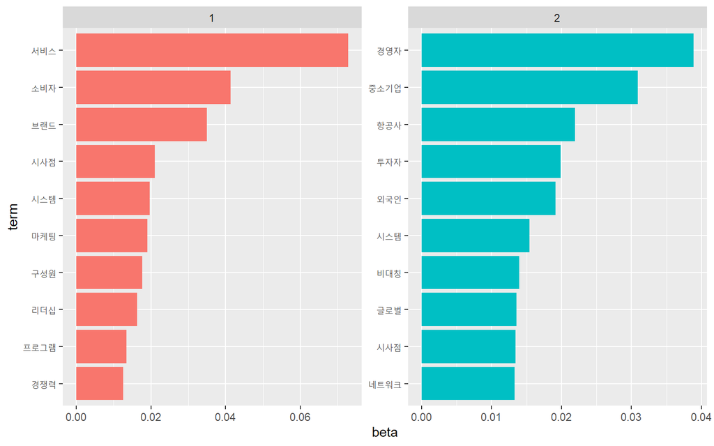

```r
# 주제별 최빈 단어 10개 확인하기: 시각화 버전.
abs_top_terms %>%
  mutate(term = reorder_within(term, beta, topic)) %>% # reorder_within(재배열할 벡터, 재배열의 기준이 될 벡터, 다면출력에 사용될 벡터)
  ggplot(aes(beta, term, fill = factor(topic))) + # topic 값이 숫자로 되어 있으므로 factor 형식으로 바꾸기.
  geom_col(show.legend = FALSE) +
  facet_wrap(~ topic, scales = "free") +
  scale_y_reordered() # y축을 내림차순으로 재배열하기.
```

- 결과해석
  - 주제 1: “서비스”, “소비자”, “브랜드” 같은 단어가 상위권. 이는 마케팅과 관련된 키워드로 보임.
  - 주제 2: “경영자”, “중소기업”, “투자”자, “외국”인 같은 단어가 상위권. 이는 경영/금융과 관련된 키워드로 보임.
  - 공통 단어: “시사점”, “시스템” 같은 단어는 주제 1, 2 모두에 걸쳐 상위권에 나타남. 여기서 “시사점”은 논문초록이라는 텍스트의 장르적 특성과 관련이 있어 보임.
- 두 주제 간에 β 값이 가장 큰 차이를 나타내는 단어 확인하기
  - 추정방법
    - 두 β 값의 로그비로 계산. $\rightarrow$ $log_2(\frac{β_2}{β_1})$.
    - $β_2$가 두 배 높으면 로그비 = 1, $β_1$이 두 배 높으면 로그비 = -1.
  - 상대적으로 빈도가 지나치게 낮은 단어들은 제외: 적어도 한 주제에서 $β>\frac{1}{1000}$인 단어만 추출하기.

```r
# 로그비 계산하기.
abstract_beta <- abstract_topics %>%
  mutate(topic = str_c("topic", topic)) %>% # topic의 값을 topic1, topic2와 같이 수정함.
  pivot_wider(names_from = topic, values_from = beta) %>% # topic1, topic2가 별도의 열이 티블의 구조를 변경함.
  filter(topic1 > .001 | topic2 > .001) %>% # 각 topic의 β 값이 0.001 이상인 행만 추출하기.
  mutate(log_ratio = log2(topic2 / topic1)) # 로그비 계산하기.
abstract_beta
```

```
## # A tibble: 296 x 4
##    term       topic1   topic2 log_ratio
##    <chr>       <dbl>    <dbl>     <dbl>
##  1 가격제   2.62e-58 1.19e- 3   182.
##  2 가맹점   3.80e- 3 1.41e-10   -24.7
##  3 가운데   2.84e- 3 2.09e- 3    -0.445
##  4 가입자   1.14e- 3 2.31e- 5    -5.63
##  5 가중치   1.65e- 3 6.64e- 4    -1.32
##  6 개발비   2.13e-11 3.10e- 3    27.1
##  7 개인주의 1.38e- 3 1.04e- 4    -3.72
##  8 거래량   6.17e- 5 2.97e- 3     5.59
##  9 거래소   3.02e-10 3.77e- 3    23.6
## 10 거시경제 2.06e- 4 2.02e- 3     3.29
## # ... with 286 more rows
```

```r
# 주제 1에 특징적인 단어들 확인하기.
topic1 <- abstract_beta %>%
  slice_min(log_ratio, n= 10) %>%
  mutate(topic = "topic1") %>%
  select(-c(2:3))
topic1
```

```
## # A tibble: 10 x 3
##    term     log_ratio topic
##    <chr>        <dbl> <chr>
##  1 사이트      -188.  topic1
##  2 테이터      -185.  topic1
##  3 스케이프    -176.  topic1
##  4 집합주의    -173.  topic1
##  5 전문점      -170.  topic1
##  6 직장인      -133.  topic1
##  7 쇼핑몰      -127.  topic1
##  8 소매상      -108.  topic1
##  9 라이프       -96.8 topic1
## 10 모바일       -91.8 topic1
```

```r
# 주제 2에 특징적인 단어들 확인하기.
topic2 <- abstract_beta %>%
  slice_max(log_ratio, n= 10) %>%
  mutate(topic = "topic2") %>%
  select(-c(2:3))
topic2
```

```
## # A tibble: 10 x 3
##    term     log_ratio topic
##    <chr>        <dbl> <chr>
##  1 반전성        202. topic2
##  2 물동량        198. topic2
##  3 이슬람        195. topic2
##  4 접대비        194. topic2
##  5 영업권        187. topic2
##  6 보수성        183. topic2
##  7 가격제        182. topic2
##  8 보수주의      180. topic2
##  9 보험증        175. topic2
## 10 매출채권      170. topic2
```

```r
# 상기 두 티블 병합하기.
topic_log_ratio <- bind_rows(topic1, topic2)
topic_log_ratio
```

```
## # A tibble: 20 x 3
##    term     log_ratio topic
##    <chr>        <dbl> <chr>
##  1 사이트      -188.  topic1
##  2 테이터      -185.  topic1
##  3 스케이프    -176.  topic1
##  4 집합주의    -173.  topic1
##  5 전문점      -170.  topic1
##  6 직장인      -133.  topic1
##  7 쇼핑몰      -127.  topic1
##  8 소매상      -108.  topic1
##  9 라이프       -96.8 topic1
## 10 모바일       -91.8 topic1
## 11 반전성       202.  topic2
## 12 물동량       198.  topic2
## 13 이슬람       195.  topic2
## 14 접대비       194.  topic2
## 15 영업권       187.  topic2
## 16 보수성       183.  topic2
## 17 가격제       182.  topic2
## 18 보수주의     180.  topic2
## 19 보험증       175.  topic2
## 20 매출채권     170.  topic2
```

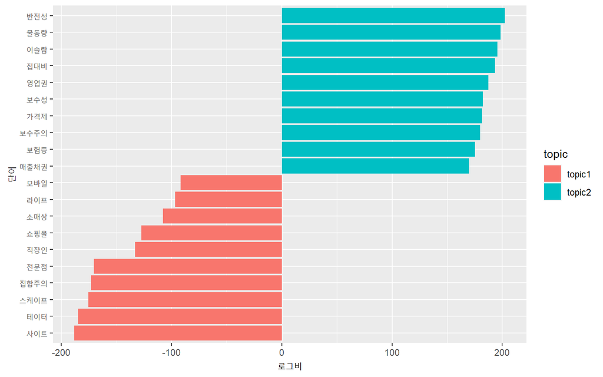

```r
# 주제별 특징적 단어 10개씩 시각화하기.
topic_log_ratio %>%
  mutate(term = reorder_within(term, log_ratio, topic)) %>%
  ggplot(aes(log_ratio, term, fill = topic)) +
  geom_col() +
  scale_y_reordered() +
  labs(x = "로그비", y = "단어")
```

- 결과해석
  - 주제 1: 소매상, 쇼핑몰, 직장인, 전문점은 판매/마케팅과 직접적 관련이 있는 단어들 위주.
  - 주제 2: 보험증, 매출채권, 보수성, 영업권은 금융/경영과 직접적 관련이 있는 단어들 위주.

##### 다. 문서-주제 확률

- `tidy` 함수: LDA 객체를 tidy 형식으로 바꿔줌.
- γ(gamma)
  - 특정 문서가 특정 주제에 할당될 확률: “모든 문서는 주제들이 무작위로 섞인 임의의 혼합물이다.”
  - `matrix` = “gamma”를 지정해주면 주제, 문서, γ 값이 제시됨.

```r
abstract_documents <- tidy(abstract_lda, matrix = "gamma")
abstract_documents
```

```
## # A tibble: 4,432 x 3
##    document      topic   gamma
##    <chr>         <int>   <dbl>
##  1 A201008176863     1 0.347
##  2 A201008176891     1 0.0133
##  3 A201008176910     1 0.995
##  4 A201008176974     1 0.496
##  5 A201008176986     1 0.0643
##  6 A201008177010     1 0.0188
##  7 A201008177018     1 0.978
##  8 A201008177027     1 0.892
##  9 A201008177043     1 0.995
## 10 A201008177058     1 0.00588
## # ... with 4,422 more rows
```

- 결과해석
  - LDA 모형을 하나의 행에 하나의 문서와 주제가 들어 있는 형식으로 변환함.
  - 각 문서-주제 조합에 대해 해당 문서가 특정 주제에 할당될 확률(γ)을 계산함.
  - 해석
    - 해당 문서에 등장하는 단어들 중에서 특정 주제로부터 생성된 단어의 비율. 문서 A201008176863에 있는 34.7퍼센트의 단어만 주제 1로부터 생성되었음.
    - 대부분의 문서에 두 주제가 혼합되어 있음을 알 수 있음. 그러나 문서 A201008177058은 거의 온전히 주제 2로부터 생성됨. 주제 1의 γ가 0.588퍼센트밖에 되지 않기 때문.
    - `tidy` 함수를 통해 DTM 객체인 `abstract_corpus.dtm.1`을 tidy 형식으로 변환한 뒤 문서 A201008177058의 빈출단어(증권/금융 관련 어휘)를 확인.

```r
# DTM 객체 abstract_corpus.dtm.1을 tidy 형식으로 변환
tidy(abstract_corpus.dtm.1) %>%
  filter(document == "A201008177058") %>%
  arrange(desc(count))
```

```
## # A tibble: 9 x 3
##   document      term   count
##   <chr>         <chr>  <dbl>
## 1 A201008177058 증권사    10
## 2 A201008177058 분석가     3
## 3 A201008177058 국내외     2
## 4 A201008177058 보고서     2
## 5 A201008177058 중소형     2
## 6 A201008177058 대부분     1
## 7 A201008177058 뒷받침     1
## 8 A201008177058 비대칭     1
## 9 A201008177058 투자자     1
```

## (2) LDA 실습: 세종형태의미분석 말뭉치 수록 4개 작품

### 1) LDA 분석을 위한 사전처리

- 실습취지
  - 작가, 주제, 문체가 서로 다른 네 작품을 바탕으로 토픽 모델링 수행.
  - 절차
    - 네 작품을 각각 20등분하여 임의의 장(chapter) 20개 생성(원래의 장을 활용하면 좋겠지만, 현 말뭉치는 장이 명확히 구분되어 있지 않음).
    - 개별 장이 각각 하나의 문서를 구성.
    - 문서들을 무작위로 섞음.
    - 토픽 모델링으로 문서들을 다시 네 작품으로 정확하게 분류할 수 있는지 확인.
  - 이미 정답을 알고 있으므로 해당 알고리즘이 정말 유용한지, 만약 오류가 발생했다면 무엇이 어디서 잘못된 것인지 확인하기 편리함.
- 작품 소개
  - 작품 1: 이문열 저 <사람의 아들>(1989). 어절수 22,526개.
  - 작품 2: 조세희 저 <난장이가 쏘아올린 작은 공>(1978). 어절 수 10,093개.
  - 작품 3: 김영하 저 <아랑은 왜>(2001). 어절 수 36,965개.
  - 작품 4: 최인훈 저 <광장>(1976). 어절 수 23,859개.
- 네 작품 말뭉치 사전처리
  1. 파일 불러와 티블 형식으로 만들기.
  2. 형태소 단위로 행 나누기.
  3. 작품별 행 수 파악한 뒤 20-21개 장(문서)으로 나누기.

```r
# 네 작품 파일 불러와 티블 형식으로 만들기.
sjnovel.list <- list.files("texts/sejong")
sjnovel.list
```

```
## [1] "BSEO0288.txt" "BSEO0316.txt" "BSEO0323.txt" "BSEO0326.txt"
```

```r
sjnovel.list.1 <- str_c("texts/sejong/", sjnovel.list)
sjnovel.list.1
```

```
## [1] "texts/sejong/BSEO0288.txt" "texts/sejong/BSEO0316.txt"
## [3] "texts/sejong/BSEO0323.txt" "texts/sejong/BSEO0326.txt"
```

```r
sjnovel.list.2 <- map(sjnovel.list.1, function(x) read_lines(x, skip = 74, locale = locale(encoding = "CP949"))) %>% # 텍스트 인코딩 "CP949"로 해주기.
  map(function(x) str_extract(x, "^9B.*")) %>% # 행 번호가 "9B"로 시작하는 행만 추출하기.
  unlist() %>% # 리스트를 벡터로 바꾸기.
  as_tibble() %>% # 벡터를 티블로 바꾸기.
  drop_na() # NA 행 제거하기.
sjnovel.list.2
```

```
## # A tibble: 93,438 x 1
##    value
##    <chr>
##  1 "9BSEO0288-0000010\t1.\t1/SN + ./SF"
##  2 "9BSEO0288-0000020\t큰줄흰나비\t크/VA + ㄴ/ETM + 줄__01/NNG + 흰나비/NNG"
##  3 "9BSEO0288-0000030\t아랑은\t아랑/NNP + 은/JX"
##  4 "9BSEO0288-0000040\t나비가\t나비__03/NNG + 가/JKC"
##  5 "9BSEO0288-0000050\t되었다고\t되__01/VV + 었/EP + 다고/EC"
##  6 "9BSEO0288-0000060\t한다.\t하/VV + ㄴ다/EF + ./SF"
##  7 "9BSEO0288-0000070\t나비.\t나비__03/NNG + ./SF"
##  8 "9BSEO0288-0000080\t어떤\t어떤/MM"
##  9 "9BSEO0288-0000090\t나비들은\t나비__03/NNG + 들/XSN + 은/JX"
## 10 "9BSEO0288-0000100\t아주\t아주/MAG"
## # ... with 93,428 more rows
```

```r
# 네 작품 말뭉치 형태소 단위로 행 나눈 뒤 제목과 작가 열 추가하기.
sjnovel.list.3 <- sjnovel.list.2 %>%
  separate(value, into = c("row_id", "text_untagged", "text_tagged"), sep = "\t") %>% # 탭 단위로 열 나누기.
  separate_rows(text_tagged, sep = " \\+ ") %>% # 형태소 단위로 행 나누기.
  separate(text_tagged, into = c("morph", "tag"), sep = "/") %>%
  mutate(text_tagged = str_c(morph, "/", tag)) %>% # 태그 부착된 형태소 열 생성하기.
  filter(str_detect(tag, "NNP|NNG")) %>% # 일반 및 고유 명사만 추출하기.
  # 말뭉치 고유 ID로 제목과 작가 분류하기.
  mutate(title = case_when(str_detect(row_id, "9BSEO0288") ~ "아랑은 왜",
                           str_detect(row_id, "9BSEO0326") ~ "난장이가 쏘아올린 작은 공",
                           str_detect(row_id, "9BSEO0316") ~ "사람의 아들",
                           str_detect(row_id, "9BSEO0323") ~ "광장"),
         author = case_when(str_detect(row_id, "9BSEO0288") ~ "김영하",
                            str_detect(row_id, "9BSEO0326") ~ "조세희",
                            str_detect(row_id, "9BSEO0316") ~ "이문열",
                            str_detect(row_id, "9BSEO0323") ~ "최인훈")
         )
sjnovel.list.3
```

```
## # A tibble: 41,227 x 7
##    row_id            text_untagged    morph    tag   text_tagged  title   author
##    <chr>             <chr>            <chr>    <chr> <chr>        <chr>   <chr>
##  1 9BSEO0288-0000020 큰줄흰나비       줄__01   NNG   줄__01/NNG   아랑은~ 김영하
##  2 9BSEO0288-0000020 큰줄흰나비       흰나비   NNG   흰나비/NNG   아랑은~ 김영하
##  3 9BSEO0288-0000030 아랑은           아랑     NNP   아랑/NNP     아랑은~ 김영하
##  4 9BSEO0288-0000040 나비가           나비__03 NNG   나비__03/NNG 아랑은~ 김영하
##  5 9BSEO0288-0000070 나비.            나비__03 NNG   나비__03/NNG 아랑은~ 김영하
##  6 9BSEO0288-0000090 나비들은         나비__03 NNG   나비__03/NNG 아랑은~ 김영하
##  7 9BSEO0288-0000130 우리나라에도     우리나라 NNG   우리나라/NNG 아랑은~ 김영하
##  8 9BSEO0288-0000140 서식하는         서식__02 NNG   서식__02/NNG 아랑은~ 김영하
##  9 9BSEO0288-0000150 작은멋쟁이나비의 멋       NNG   멋/NNG       아랑은~ 김영하
## 10 9BSEO0288-0000150 작은멋쟁이나비의 나비__03 NNG   나비__03/NNG 아랑은~ 김영하
## # ... with 41,217 more rows
```

```r
# 네 작품의 행 수 파악한 뒤 20-21개 장(문서)으로 나누기.

kim <- sjnovel.list.3 %>%
  filter(author == "김영하") %>% # 16,924행 => 16924 %/% 20 => 846 + 4
  mutate(chapter = c(rep(1:20, each = 846), rep(21, 4)))
kim
```

```
## # A tibble: 16,924 x 8
##    row_id            text_untagged morph  tag   text_tagged title author chapter
##    <chr>             <chr>         <chr>  <chr> <chr>       <chr> <chr>    <dbl>
##  1 9BSEO0288-0000020 큰줄흰나비    줄__01 NNG   줄__01/NNG  아랑~ 김영하       1
##  2 9BSEO0288-0000020 큰줄흰나비    흰나비 NNG   흰나비/NNG  아랑~ 김영하       1
##  3 9BSEO0288-0000030 아랑은        아랑   NNP   아랑/NNP    아랑~ 김영하       1
##  4 9BSEO0288-0000040 나비가        나비_~ NNG   나비__03/N~ 아랑~ 김영하       1
##  5 9BSEO0288-0000070 나비.         나비_~ NNG   나비__03/N~ 아랑~ 김영하       1
##  6 9BSEO0288-0000090 나비들은      나비_~ NNG   나비__03/N~ 아랑~ 김영하       1
##  7 9BSEO0288-0000130 우리나라에도  우리~  NNG   우리나라/N~ 아랑~ 김영하       1
##  8 9BSEO0288-0000140 서식하는      서식_~ NNG   서식__02/N~ 아랑~ 김영하       1
##  9 9BSEO0288-0000150 작은멋쟁이나~ 멋     NNG   멋/NNG      아랑~ 김영하       1
## 10 9BSEO0288-0000150 작은멋쟁이나~ 나비_~ NNG   나비__03/N~ 아랑~ 김영하       1
## # ... with 16,914 more rows
```

```r
cho <- sjnovel.list.3 %>%
  filter(author == "조세희") %>% # 4,379행 => 4379 %/% 20 => 218 + 19
  mutate(chapter = c(rep(1:20, each = 218), rep(21, 19)))
cho
```

```
## # A tibble: 4,379 x 8
##    row_id            text_untagged morph  tag   text_tagged title author chapter
##    <chr>             <chr>         <chr>  <chr> <chr>       <chr> <chr>    <dbl>
##  1 9BSEO0326-0000010 난장이가      난장이 NNG   난장이/NNG  난장~ 조세희       1
##  2 9BSEO0326-0000040 공            공__01 NNG   공__01/NNG  난장~ 조세희       1
##  3 9BSEO0326-0000060 사람들은      사람   NNG   사람/NNG    난장~ 조세희       1
##  4 9BSEO0326-0000070 아버지를      아버지 NNG   아버지/NNG  난장~ 조세희       1
##  5 9BSEO0326-0000080 난장이라고    난장이 NNG   난장이/NNG  난장~ 조세희       1
##  6 9BSEO0326-0000100 사람들은      사람   NNG   사람/NNG    난장~ 조세희       1
##  7 9BSEO0326-0000130 아버지는      아버지 NNG   아버지/NNG  난장~ 조세희       1
##  8 9BSEO0326-0000140 난장이였다.   난장이 NNG   난장이/NNG  난장~ 조세희       1
##  9 9BSEO0326-0000150 불행하게도    불행   NNG   불행/NNG    난장~ 조세희       1
## 10 9BSEO0326-0000160 사람들은      사람   NNG   사람/NNG    난장~ 조세희       1
## # ... with 4,369 more rows
```

```r
lee <- sjnovel.list.3 %>%
  filter(author == "이문열") %>% # 10,095행 => 10095 %/% 20 => 504 + 15
  mutate(chapter = c(rep(1:20, each = 504), rep(21, 15)))
lee
```

```
## # A tibble: 10,095 x 8
##    row_id            text_untagged  morph tag   text_tagged title author chapter
##    <chr>             <chr>          <chr> <chr> <chr>       <chr> <chr>    <dbl>
##  1 9BSEO0316-0000010 빗방울이       빗방~ NNG   빗방울/NNG  사람~ 이문열       1
##  2 9BSEO0316-0000040 먼지           먼지~ NNG   먼지__01/N~ 사람~ 이문열       1
##  3 9BSEO0316-0000050 위에           위__~ NNG   위__01/NNG  사람~ 이문열       1
##  4 9BSEO0316-0000080 얼룩들로       얼룩  NNG   얼룩/NNG    사람~ 이문열       1
##  5 9BSEO0316-0000100 형사계(刑事係) 형사~ NNG   형사__02/N~ 사람~ 이문열       1
##  6 9BSEO0316-0000110 유리창         유리~ NNG   유리창/NNG  사람~ 이문열       1
##  7 9BSEO0316-0000140 도회의         도회~ NNG   도회__01/N~ 사람~ 이문열       1
##  8 9BSEO0316-0000150 하늘과         하늘  NNG   하늘/NNG    사람~ 이문열       1
##  9 9BSEO0316-0000170 아래           아래~ NNG   아래__01/N~ 사람~ 이문열       1
## 10 9BSEO0316-0000210 지붕들이       지붕  NNG   지붕/NNG    사람~ 이문열       1
## # ... with 10,085 more rows
```

```r
choi <- sjnovel.list.3 %>%
  filter(author == "최인훈") %>% # 9,829행 => 9829 %/% 20 => 491 + 9
  mutate(chapter = c(rep(1:20, each = 491), rep(21, 9)))
choi
```

```
## # A tibble: 9,829 x 8
##    row_id            text_untagged morph  tag   text_tagged title author chapter
##    <chr>             <chr>         <chr>  <chr> <chr>       <chr> <chr>    <dbl>
##  1 9BSEO0323-0000010 바다는,       바다   NNG   바다/NNG    광장  최인훈       1
##  2 9BSEO0323-0000020 크레파스보다  크레~  NNG   크레파스/N~ 광장  최인훈       1
##  3 9BSEO0323-0000060 비늘을        비늘_~ NNG   비늘__01/N~ 광장  최인훈       1
##  4 9BSEO0323-0000090 숨을          숨__01 NNG   숨__01/NNG  광장  최인훈       1
##  5 9BSEO0323-0000110 중립국으로    중립국 NNG   중립국/NNG  광장  최인훈       1
##  6 9BSEO0323-0000130 석방          석방   NNG   석방/NNG    광장  최인훈       1
##  7 9BSEO0323-0000140 포로를        포로_~ NNG   포로__01/N~ 광장  최인훈       1
##  8 9BSEO0323-0000160 인도          인도   NNP   인도/NNP    광장  최인훈       1
##  9 9BSEO0323-0000170 배            배     NNP   배/NNP      광장  최인훈       1
## 10 9BSEO0323-0000180 타고르호는,   타고~  NNP   타고르호/N~ 광장  최인훈       1
## # ... with 9,819 more rows
```

- 네 작품 말뭉치 tidy 텍스트 형식으로 만들기
  1. 형태소 단위로 토큰화하기.
  2. 문서별 단어 빈도 구하기.

```r
# 형태소 단위로 토큰화하기.
sjnovel.tokenized <- bind_rows(kim, cho, lee, choi) %>%
  mutate(document = str_c(title, "_", chapter)) %>% # 개별 문서 = 작품명_장 번호.
  unnest_tokens(word, morph, token = "sentences") # 형태의미분석 태그 유지하기 위해 토큰화 방법을 "문장"으로 지정.
sjnovel.tokenized
```

```
## # A tibble: 41,227 x 9
##    row_id    text_untagged tag   text_tagged title author chapter document word
##    <chr>     <chr>         <chr> <chr>       <chr> <chr>    <dbl> <chr>    <chr>
##  1 9BSEO028~ 큰줄흰나비    NNG   줄__01/NNG  아랑~ 김영하       1 아랑은 ~ 줄__~
##  2 9BSEO028~ 큰줄흰나비    NNG   흰나비/NNG  아랑~ 김영하       1 아랑은 ~ 흰나~
##  3 9BSEO028~ 아랑은        NNP   아랑/NNP    아랑~ 김영하       1 아랑은 ~ 아랑
##  4 9BSEO028~ 나비가        NNG   나비__03/N~ 아랑~ 김영하       1 아랑은 ~ 나비~
##  5 9BSEO028~ 나비.         NNG   나비__03/N~ 아랑~ 김영하       1 아랑은 ~ 나비~
##  6 9BSEO028~ 나비들은      NNG   나비__03/N~ 아랑~ 김영하       1 아랑은 ~ 나비~
##  7 9BSEO028~ 우리나라에도  NNG   우리나라/N~ 아랑~ 김영하       1 아랑은 ~ 우리~
##  8 9BSEO028~ 서식하는      NNG   서식__02/N~ 아랑~ 김영하       1 아랑은 ~ 서식~
##  9 9BSEO028~ 작은멋쟁이나~ NNG   멋/NNG      아랑~ 김영하       1 아랑은 ~ 멋
## 10 9BSEO028~ 작은멋쟁이나~ NNG   나비__03/N~ 아랑~ 김영하       1 아랑은 ~ 나비~
## # ... with 41,217 more rows
```

```r
# 문서(작품의 장)별 단어 빈도 구하기.
sjnovel.word_counts <- sjnovel.tokenized %>%
  count(document, word, sort = T)
sjnovel.word_counts
```

```
## # A tibble: 23,093 x 3
##    document       word         n
##    <chr>          <chr>    <int>
##  1 아랑은 왜_1    아랑        45
##  2 아랑은 왜_2    아랑        44
##  3 사람의 아들_15 아들        41
##  4 아랑은 왜_17   호장__02    38
##  5 아랑은 왜_16   호장__02    37
##  6 아랑은 왜_17   어사__01    37
##  7 아랑은 왜_9    영주        37
##  8 아랑은 왜_14   영주        36
##  9 사람의 아들_15 영감__01    33
## 10 사람의 아들_15 조          33
## # ... with 23,083 more rows
```

### 2) LDA 실행하기

#### A. `LDA` 함수로 LDA 실행하기

- `cast_dtm`: 하나의 행에 하나의 토큰을 할당하는 tidy 텍스트를 DTM(`DocumentTermMatrix`) 형식으로 변환해주는 함수.

```r
# tidy 텍스트를 DTM 형식으로 변환하기.
sjnovel.chapters_dtm <- sjnovel.word_counts %>%
  cast_dtm(document, word, n)
sjnovel.chapters_dtm
```

```
## <<DocumentTermMatrix (documents: 84, terms: 7869)>>
## Non-/sparse entries: 23093/637903
## Sparsity           : 97%
## Maximal term length: 9
## Weighting          : term frequency (tf)
```

- `LDA` 함수로 4-주제 LDA 모형 생성하기: 서로 다른 작가의 작품이 총 네 개이므로 4-주제 LDA 모형이 적합한지 확인하기.

```r
# 4-주제 LDA 모형 생성하기.
sjnovel.chapters_lda <- LDA(sjnovel.chapters_dtm, k = 4, control = list(seed = 1234)) # seed를 고정하면 다음에도 똑같은 결과를 재현할 수 있음.
sjnovel.chapters_lda
```

```
## A LDA_VEM topic model with 4 topics.
```

#### B. 단어-주제 확률

- `tidy` 함수를 사용하여 특정 단어가 특정 주제에 할당될 확률인 β 구하기.

```r
sjnovel.chapter_topics <- tidy(sjnovel.chapters_lda, matrix = "beta")
sjnovel.chapter_topics
```

```
## # A tibble: 31,476 x 3
##    topic term         beta
##    <int> <chr>       <dbl>
##  1     1 아랑     1.40e- 2
##  2     2 아랑     1.32e-24
##  3     3 아랑     8.54e- 3
##  4     4 아랑     9.21e-14
##  5     1 아들     7.29e- 4
##  6     2 아들     1.27e- 2
##  7     3 아들     0
##  8     4 아들     1.00e- 3
##  9     1 호장__02 3.72e-44
## 10     2 호장__02 7.02e-17
## # ... with 31,466 more rows
```

```r
# 주제별 최빈 단어 10개 확인하기: 티블 버전.
sjnovel_top_terms <- sjnovel.chapter_topics %>%
  group_by(topic) %>% # 주제별로 grouping하기.
  slice_max(beta, n = 5) %>% # 상위빈도 10개 단어만 서브세팅.
  ungroup() %>% # grouping 풀기.
  arrange(topic, -beta) # 주제 오름차순, β 내림차순으로 배열하기.
sjnovel_top_terms
```

```
## # A tibble: 20 x 3
##    topic term       beta
##    <int> <chr>     <dbl>
##  1     1 말__01   0.0256
##  2     1 아버지   0.0213
##  3     1 일__01   0.0167
##  4     1 사람     0.0160
##  5     1 아랑     0.0140
##  6     2 말__01   0.0153
##  7     2 남       0.0148
##  8     2 경사__14 0.0147
##  9     2 사람     0.0145
## 10     2 아하스   0.0136
## 11     3 말__01   0.0177
## 12     3 억균     0.0155
## 13     3 영주     0.0149
## 14     3 일__01   0.0133
## 15     3 호장__02 0.0118
## 16     4 명준     0.0254
## 17     4 사람     0.0244
## 18     4 말__01   0.0227
## 19     4 일__01   0.0185
## 20     4 때__01   0.0143
```

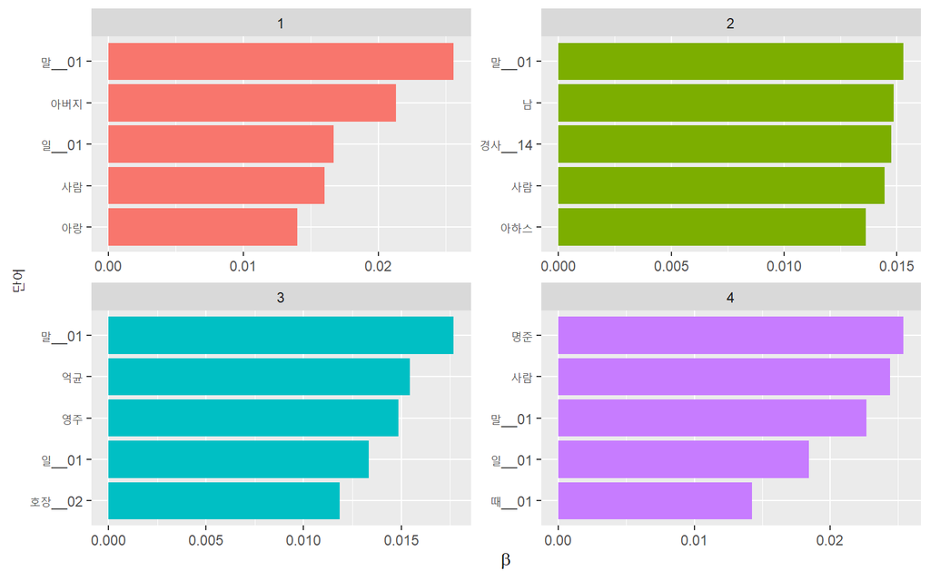

```r
# 주제별 최빈 단어 10개 확인하기: 시각화 버전.
sjnovel_top_terms %>%
  mutate(term = reorder_within(term, beta, topic)) %>% # reorder_within(재배열할 벡터, 재배열의 기준이 될 벡터, 다면출력에 사용될 벡터)
  ggplot(aes(beta, term, fill = factor(topic))) + # topic 값이 숫자로 되어 있으므로 factor 형식으로 바꾸기.
  geom_col(show.legend = FALSE) +
  facet_wrap(~ topic, scales = "free") +
  scale_y_reordered() + # y축을 내림차순으로 재배열하기.
  labs(x = expression(beta), y = "단어") # β는 자판에 없는 문자이므로 expression이라는 함수로 감싸주어야 플롯에 그리스어로 출력됨.
```

#### C. 문서-주제 확률

- γ: 본 분석에서는 하나의 장이 개별 문서에 해당. 어떤 주제가 각 장과 연관이 있는지 γ(특정 문서가 특정 주제에 할당될 확률)를 통해 확인할 수 있음.

```r
sjnovel.gamma <- tidy(sjnovel.chapters_lda, matrix = "gamma")
sjnovel.gamma
```

```
## # A tibble: 336 x 3
##    document       topic     gamma
##    <chr>          <int>     <dbl>
##  1 아랑은 왜_1        1 1.00
##  2 아랑은 왜_2        1 1.00
##  3 사람의 아들_15     1 0.0158
##  4 아랑은 왜_17       1 0.0000172
##  5 아랑은 왜_16       1 0.0000172
##  6 아랑은 왜_9        1 0.0000172
##  7 아랑은 왜_14       1 0.00587
##  8 사람의 아들_19     1 0.0000288
##  9 아랑은 왜_13       1 0.0000172
## 10 광장_12            1 0.0000296
## # ... with 326 more rows
```

```r
# 문서의 이름을 소설 제목과 장으로 분리하기.
sjnovel.gamma.1 <- sjnovel.gamma %>%
  separate(document, c("title", "chapter"), sep = "_") %>%
  mutate(chapter = as.numeric(chapter))
sjnovel.gamma.1
```

```
## # A tibble: 336 x 4
##    title       chapter topic     gamma
##    <chr>         <dbl> <int>     <dbl>
##  1 아랑은 왜         1     1 1.00
##  2 아랑은 왜         2     1 1.00
##  3 사람의 아들      15     1 0.0158
##  4 아랑은 왜        17     1 0.0000172
##  5 아랑은 왜        16     1 0.0000172
##  6 아랑은 왜         9     1 0.0000172
##  7 아랑은 왜        14     1 0.00587
##  8 사람의 아들      19     1 0.0000288
##  9 아랑은 왜        13     1 0.0000172
## 10 광장             12     1 0.0000296
## # ... with 326 more rows
```

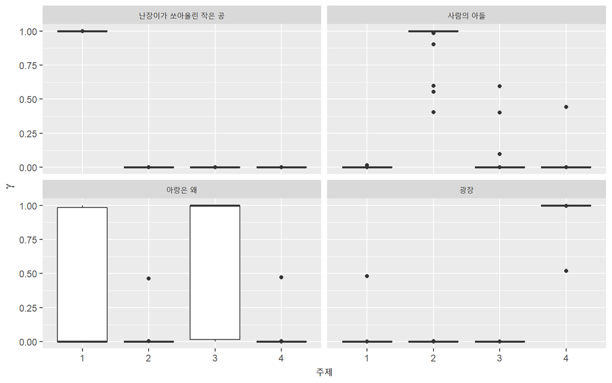

```r
# 작품별 γ 시각화하기.
sjnovel.gamma.1 %>%
  mutate(title = reorder(title, gamma * topic)) %>%
  ggplot(aes(factor(topic), gamma)) + # x축은 주제, y축은 gamma로 설정.
  geom_boxplot() + # 상자 그래프로 나타냄.
  facet_wrap(~ title) + # 작품명별로 다면출력.
  labs(x = "주제", y = expression(gamma)) # x축과 y축에 레이블 추가하기.
```

- 결과해석
  - <난장이가 쏘아올린 작은 공>, <사람의 아들>, <광장>은 거의 모든 장이 각각 하나의 주제를 가진 것으로 나타남.
  - <아랑은 왜>(주제 3에 해당)의 몇몇 장은 다른 주제, 특히 주제 1(<난장이가 쏘아올린 작은 공>)과도 연관성이 있는 것으로 보임.
- 장별 주제분류
  1. 각 장과 가장 연관성이 높은 주제 찾기: `slice_max` 함수를 사용하여 각 작품의 장별로 γ를 제시함으로써 네 작품의 각 장이 네 주제에 어떻게 분류되어 있는지 확인할 수 있음.
  2. 주제와 일치하지 않는 작품의 장 찾아내기.

```r
# 각 장에 할당된 주제와 γ 수치를 작품과 장 순서대로 제시하기.
sjnovel.classifications <- sjnovel.gamma.1 %>%
  group_by(title, chapter) %>% # 작품과 장 별로 grouping하기.
  slice_max(gamma) %>% # 각 작품의 장별로 가장 높은 gamma 수치 보여주기.
  ungroup()
sjnovel.classifications
```

```
## # A tibble: 84 x 4
##    title chapter topic gamma
##    <chr>   <dbl> <int> <dbl>
##  1 광장        1     4 1.00
##  2 광장        2     4 1.00
##  3 광장        3     4 1.00
##  4 광장        4     4 1.00
##  5 광장        5     4 1.00
##  6 광장        6     4 0.518
##  7 광장        7     4 1.00
##  8 광장        8     4 1.00
##  9 광장        9     4 0.997
## 10 광장       10     4 1.00
## # ... with 74 more rows
```

```r
# 작품별로 몇 개의 장이 특정 주제에 할당되어 있는지 확인하기.
sjnovel.classifications %>%
  count(title, topic) # 작품명과 주제 기준으로 빈도 분석하기.
```

```
## # A tibble: 6 x 3
##   title                     topic     n
##   <chr>                     <int> <int>
## 1 광장                          4    21
## 2 난장이가 쏘아올린 작은 공     1    21
## 3 사람의 아들                   2    20
## 4 사람의 아들                   3     1
## 5 아랑은 왜                     1     7
## 6 아랑은 왜                     3    14
```

```r
# 작품명 열 + 해당 작품과 가장 연관성이 높은 주제 열로 구성된 티블 만들기.
book_topics <- sjnovel.classifications %>%
  count(title, topic) %>%
  group_by(title) %>% # 작품명에 따라 grouping하기.
  slice_max(n, n = 1) %>% # n이 가장 높은 행 하나만 서브세팅하기.
  ungroup() %>%
  transmute(consensus = title, topic) # consensus 열 추가하고 topic 열 남긴 뒤 다른 열 모두 지우기.
book_topics
```

```
## # A tibble: 4 x 2
##   consensus                 topic
##   <chr>                     <int>
## 1 광장                          4
## 2 난장이가 쏘아올린 작은 공     1
## 3 사람의 아들                   2
## 4 아랑은 왜                     3
```

```r
# 작품명과 LDA의 예측이 일치하지 않는 장 추출하기.
sjnovel.classifications %>%
  inner_join(book_topics, by = "topic") %>% # topic 열을 기준으로 sjnovel.classifications와 book_topics를 합치기.
  filter(title != consensus) # 작품명과 LDA의 예측이 일치하지 않는 장 추출하기.
```

```
## # A tibble: 8 x 5
##   title       chapter topic gamma consensus
##   <chr>         <dbl> <int> <dbl> <chr>
## 1 사람의 아들       1     3 0.596 아랑은 왜
## 2 아랑은 왜         1     1 1.00  난장이가 쏘아올린 작은 공
## 3 아랑은 왜         2     1 1.00  난장이가 쏘아올린 작은 공
## 4 아랑은 왜         3     1 0.985 난장이가 쏘아올린 작은 공
## 5 아랑은 왜         4     1 1.00  난장이가 쏘아올린 작은 공
## 6 아랑은 왜         5     1 1.00  난장이가 쏘아올린 작은 공
## 7 아랑은 왜         6     1 0.972 난장이가 쏘아올린 작은 공
## 8 아랑은 왜        21     1 0.989 난장이가 쏘아올린 작은 공
```

#### D. 단어별 주제할당

- γ 이외의 주제할당 정보: 각 장(문서)의 어떤 단어가 어떤 주제에 할당되었는지를 원래 문서-단어 쌍과 비교하여 살펴볼 경우, γ만으로 알기 힘든 추가정보를 얻을 수 있음.
- `augment` 함수
  - **broom** 패키지에서 유래.
  - 통계모형의 출력을 tidy 형식으로 제시해줌.
  - `tidy` 함수와의 차이점: 통계모형을 사용하여 원 데이터에 추가정보를 덧붙여줌.
  - 주요 논항: `x` = 통계모형 모형, `data` = DTM 데이터.
  - 반환해주는 결과: 장(문서)별 단어 빈도 및 문서가 할당된 주제. 새로이 추가되는 열 제목 앞에는 `.`를 붙여 기존 열을 덮어쓰지 않도록 방지.

```r
sjnovel.assignments <- augment(sjnovel.chapters_lda, data = sjnovel.chapters_dtm)
sjnovel.assignments
```

```
## # A tibble: 23,093 x 4
##    document     term  count .topic
##    <chr>        <chr> <dbl>  <dbl>
##  1 아랑은 왜_1  아랑     45      1
##  2 아랑은 왜_2  아랑     44      1
##  3 아랑은 왜_17 아랑     13      3
##  4 아랑은 왜_16 아랑      3      3
##  5 아랑은 왜_9  아랑      1      3
##  6 아랑은 왜_13 아랑     18      3
##  7 아랑은 왜_18 아랑      2      3
##  8 아랑은 왜_20 아랑     26      3
##  9 아랑은 왜_12 아랑      5      3
## 10 아랑은 왜_15 아랑      4      3
## # ... with 23,083 more rows
```

- 오분류 단어 확인하기: `sjnovel.assignments` 티블과 `book_topics`(작품명과 주제) 티블을 병합하여 어떤 단어가 오분류되었는지 살펴보기.

```r
# 단어별 주제분류 확인하기.
sjnovel.word.classification <- sjnovel.assignments %>%
  separate(document, c("title", "chapter"), sep = "_") %>% # 언더바로 연결된 문서명을 작품명과 장으로 분리하기.
  inner_join(book_topics, by = c(".topic" = "topic")) %>% # 주제를 기준으로 book_topics 티블과 결합하기
  rename(topic = `.topic`) # 열 이름 수정하기.
sjnovel.word.classification
```

```
## # A tibble: 23,093 x 6
##    title     chapter term  count topic consensus
##    <chr>     <chr>   <chr> <dbl> <dbl> <chr>
##  1 아랑은 왜 1       아랑     45     1 난장이가 쏘아올린 작은 공
##  2 아랑은 왜 2       아랑     44     1 난장이가 쏘아올린 작은 공
##  3 아랑은 왜 17      아랑     13     3 아랑은 왜
##  4 아랑은 왜 16      아랑      3     3 아랑은 왜
##  5 아랑은 왜 9       아랑      1     3 아랑은 왜
##  6 아랑은 왜 13      아랑     18     3 아랑은 왜
##  7 아랑은 왜 18      아랑      2     3 아랑은 왜
##  8 아랑은 왜 20      아랑     26     3 아랑은 왜
##  9 아랑은 왜 12      아랑      5     3 아랑은 왜
## 10 아랑은 왜 15      아랑      4     3 아랑은 왜
## # ... with 23,083 more rows
```

```r
# 오분류 단어 확인하기.
sjnovel.misword <- sjnovel.word.classification %>%
  filter(title != consensus) # 작품명이 LDA의 예측과 일치하지 않는 장의 단어들 추출하기.
sjnovel.misword
```

```
## # A tibble: 3,896 x 6
##    title     chapter term     count topic consensus
##    <chr>     <chr>   <chr>    <dbl> <dbl> <chr>
##  1 아랑은 왜 1       아랑        45     1 난장이가 쏘아올린 작은 공
##  2 아랑은 왜 2       아랑        44     1 난장이가 쏘아올린 작은 공
##  3 아랑은 왜 4       아랑         7     1 난장이가 쏘아올린 작은 공
##  4 아랑은 왜 6       아랑        19     1 난장이가 쏘아올린 작은 공
##  5 아랑은 왜 3       아랑        14     1 난장이가 쏘아올린 작은 공
##  6 아랑은 왜 5       아랑         7     1 난장이가 쏘아올린 작은 공
##  7 아랑은 왜 4       아들         2     1 난장이가 쏘아올린 작은 공
##  8 아랑은 왜 5       아들         2     1 난장이가 쏘아올린 작은 공
##  9 아랑은 왜 4       어사__01    18     1 난장이가 쏘아올린 작은 공
## 10 아랑은 왜 6       어사__01    14     1 난장이가 쏘아올린 작은 공
## # ... with 3,886 more rows
```

- 오차행렬(confusion matrix)
  - 정의: 모형이 학습 후 얼마나 잘 예측을 수행해주는지 그 성능을 측정하기 위해 예측된 값과 실제 값을 시각적으로 비교한 표.
  - 예시: 특정 작품에 나오는 단어들이 얼마나 자주 다른 작품에 할당되었는지를 보여줌.
  - 함수: 빈도측정용 `count`, 타일 모양으로 오차행렬을 시각화해주는 `geom_tile` 사용.

```r
library(scales) # 특정 주제(작품)에 할당된 단어들의 비율을 퍼센트 형식(percent_format())으로 제시하는 데 필요.

# 단어빈도 가중치 없이 title과 cosensus 간 조합 빈도 분석하기.
sjnovel.word.classification %>%
  count(title, consensus) # title과 cosensus 간 조합의 수만 반환.
```

```
## # A tibble: 12 x 3
##    title                     consensus                     n
##    <chr>                     <chr>                     <int>
##  1 광장                      광장                       5455
##  2 광장                      난장이가 쏘아올린 작은 공   166
##  3 광장                      사람의 아들                   1
##  4 난장이가 쏘아올린 작은 공 난장이가 쏘아올린 작은 공  2465
##  5 사람의 아들               광장                          6
##  6 사람의 아들               난장이가 쏘아올린 작은 공     5
##  7 사람의 아들               사람의 아들                5496
##  8 사람의 아들               아랑은 왜                   377
##  9 아랑은 왜                 광장                        244
## 10 아랑은 왜                 난장이가 쏘아올린 작은 공  2837
## 11 아랑은 왜                 사람의 아들                 260
## 12 아랑은 왜                 아랑은 왜                  5781
```

```r
# 단어빈도를 가중치로 설정하여 title과 cosensus 간 조합 빈도 분석하기.
sjnovel.word.classification %>%
  count(title, consensus, wt = count) # 대다수 단어는 같은 장에 여러 번 등장. 따라서 가중치(weight, wt)를 count로 설정해야 단어들의 반복출현을 고려하여 title과 cosensus 간 조합 빈도 계산 가능.
```

```
## # A tibble: 12 x 3
##    title                     consensus                     n
##    <chr>                     <chr>                     <dbl>
##  1 광장                      광장                       9601
##  2 광장                      난장이가 쏘아올린 작은 공   227
##  3 광장                      사람의 아들                   1
##  4 난장이가 쏘아올린 작은 공 난장이가 쏘아올린 작은 공  4379
##  5 사람의 아들               광장                          7
##  6 사람의 아들               난장이가 쏘아올린 작은 공     5
##  7 사람의 아들               사람의 아들                9572
##  8 사람의 아들               아랑은 왜                   511
##  9 아랑은 왜                 광장                        433
## 10 아랑은 왜                 난장이가 쏘아올린 작은 공  5074
## 11 아랑은 왜                 사람의 아들                 381
## 12 아랑은 왜                 아랑은 왜                 11036
```

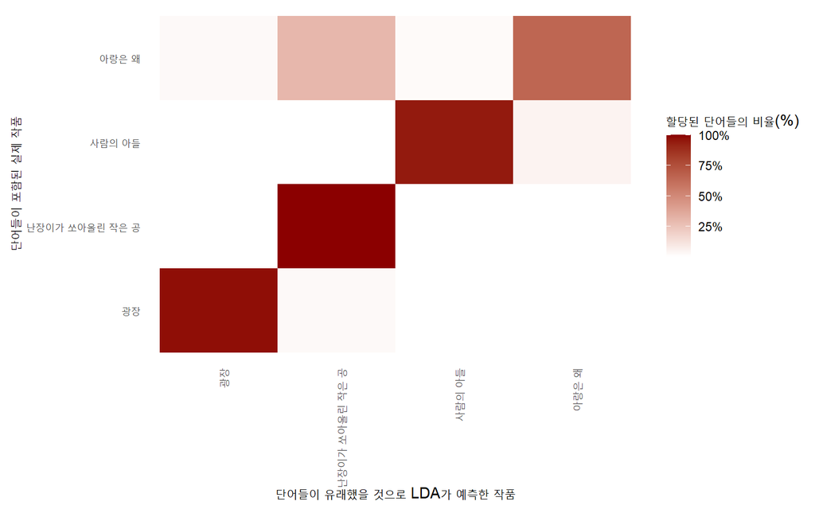

```r
# 오차행렬 시각화하기.
sjnovel.word.classification %>%
  count(title, consensus, wt = count) %>%
  group_by(title) %>%
  mutate(percent = n / sum(n)) %>% # 주제별 단어 출현 비율 열 추가하기.
  ggplot(aes(consensus, title, fill = percent)) + # x축 = consensus, y축 = title, 타일색 = percent.
  geom_tile() + # 타일 모양으로 단어할당 비율 나타내기.
  scale_fill_gradient2(high = "darkred", label = percent_format()) + # 타일색에 그라데이션 효과 주기. 관찰값이 높을수록 어두운 빨간색에 가깝도록 표현. 레이블은 퍼센트 형식으로 나타내기.
  theme_minimal() + # 배경색과 눈금 없애기.
  theme(axis.text.x = element_text(angle = 90, hjust = 1), # x축 텍스트를 90도로 뉘여 제시하기.
        panel.grid = element_blank()) +
  labs(x = "단어들이 유래했을 것으로 LDA가 예측한 작품",
       y = "단어들이 포함된 실제 작품",
       fill = "할당된 단어들의 비율(%)")
```

- 결과해석
  - <광장>, <사람의 아들>, <난장이가 쏘아올린 작은 공>은 거의 모든 단어가 주제에 맞게 정확히 할당됨 $\rightarrow$ LDA 모형의 예측성능 높음.
  - <아랑은 왜>는 상당 수의 단어가 오분류되어 있음. 이는 7개의 장이 오분류되어 있던 것과 일맥상통함.
- 오분류 단어 빈도 분석: `count` 함수로 오분류 단어들의 빈도 분석하기.

```r
# 오분류 단어 빈도 확인하기.
sjnovel.misword %>%
  count(title, consensus, term, wt = count) %>% # 특정 title-consensus-term 조합에서 출현하는 단어들의 빈도 분석하기.
  ungroup() %>%
  arrange(desc(n)) # 빈도순으로 배열하기.
```

```
## # A tibble: 2,970 x 4
##    title     consensus                 term         n
##    <chr>     <chr>                     <chr>    <dbl>
##  1 아랑은 왜 난장이가 쏘아올린 작은 공 아랑       136
##  2 아랑은 왜 난장이가 쏘아올린 작은 공 이야기     114
##  3 아랑은 왜 난장이가 쏘아올린 작은 공 부사__03    58
##  4 아랑은 왜 난장이가 쏘아올린 작은 공 말__01      54
##  5 아랑은 왜 난장이가 쏘아올린 작은 공 사람        54
##  6 아랑은 왜 난장이가 쏘아올린 작은 공 밀양        51
##  7 아랑은 왜 난장이가 쏘아올린 작은 공 일__01      49
##  8 아랑은 왜 난장이가 쏘아올린 작은 공 인물        45
##  9 아랑은 왜 난장이가 쏘아올린 작은 공 나비__03    43
## 10 아랑은 왜 난장이가 쏘아올린 작은 공 전설__04    43
## # ... with 2,960 more rows
```

```r
# "아랑"의 출현 작품 및 빈도 확인하기.
sjnovel.word_counts %>%
  filter(word == "아랑")
```

```
## # A tibble: 18 x 3
##    document     word      n
##    <chr>        <chr> <int>
##  1 아랑은 왜_1  아랑     45
##  2 아랑은 왜_2  아랑     44
##  3 아랑은 왜_20 아랑     26
##  4 아랑은 왜_6  아랑     19
##  5 아랑은 왜_13 아랑     18
##  6 아랑은 왜_3  아랑     14
##  7 아랑은 왜_17 아랑     13
##  8 아랑은 왜_7  아랑     13
##  9 아랑은 왜_10 아랑      8
## 10 아랑은 왜_4  아랑      7
## 11 아랑은 왜_5  아랑      7
## 12 아랑은 왜_11 아랑      5
## 13 아랑은 왜_12 아랑      5
## 14 아랑은 왜_15 아랑      4
## 15 아랑은 왜_16 아랑      3
## 16 아랑은 왜_18 아랑      2
## 17 아랑은 왜_8  아랑      1
## 18 아랑은 왜_9  아랑      1
```

- 결과해석
  - 실제로 <아랑은 왜>에 출현했음에도 LDA 모형은 <난장이가 쏘아올린 작은 공>으로 예측한 단어들이 많은 것을 알 수 있음.
  - 특히 “아랑”이나 “밀양”은 <난장이가 쏘아올린 작은 공>에 한 차례도 등장하지 않았음.
  - “이야기”, “사람”, “일__01”은 두 작품에 공통으로 등장하는 횟수가 많음.
  - LDA 알고리즘은 확률에 의존하므로 하나의 주제가 우연히 여러 작품에 걸쳐 할당될 가능성을 배제할 수 없음.

### 4) LDA 교차검증하기

#### 1) 원리

- 교차검증(cross-validation)
  - 상기 실습에서는 주제의 수(4개)를 사용자가 미리 알고 있었음.
  - 현실에서는 사용자가 최상의 주제 수를 미리 알고 있지 못함. 이럴 때 교차검증 방법을 사용할 수 있음.
  - 5겹 교차검증(5-fold cross-validation) 예시: 데이터를 5조각으로 나누기. $\rightarrow$ 데이터의 4조각으로 모형의 적합도를 추정하고, 나머지 한 조각은 모형의 적합도를 평가하기 위해 사용함. $\rightarrow$ 주어진 주제 수에 대해 교차검증 실행(주제 2개일 때, 주제가 3개 일때 … 주제가 *n*개일 때). $\rightarrow$ 모형 적합도 평가 측정치를 바탕으로 최적의 주제 수 선택.
- 퍼플렉시티(perplexity)
  - 언어모형 적합도 평가를 위해 사용하는 통계수치.
  - 언어모형이 특정 시점에서 평균적으로 몇 개의 선택지를 가지고 고민하고 있는지를 의미.
  - 수치가 낮을수록 모형의 성능이 더 좋다고 간주.
- 교차검증 절차
  1. 모형 적합도 추정: *n*조각 중 *n*-1조각 데이터로 주어진 주제 수에 대해 LDA 모형 추정하기.
  2. 모형 적합도 검증: 나머지 한 조각 데이터로 퍼플렉시티 계산하기.

#### 2) 실습

- 실습절차
  1. 초매개변수 결정
     - 주제의 개수 k의 범위: 2-12개.
     - 데이터 조각(fold)의 수: 5겹.
  2. 모형의 학습 및 검증에 사용될 데이터의 인덱스 정하기.
  3. LDA 수행하기
     - 분석대상 DTM: 경제분야 논문초록 말뭉치 DTM `abstract_corpus.dtm.1`.
     - 학습용 모형 LDA: 기존대로 수행.
     - 검증용 모형 LDA: 검증을 위해 학습용 모형 그대로 투입. 따라서 단어-주제 확률 β 따로 계산할 필요 없음.
  4. 주제의 개수별 퍼플렉시티 계산하기.
  5. 결과: 주제의 수가 늘어날수록 퍼플렉시티도 줄어듦. 12개일 때가 최소. $\rightarrow$ 주제의 수가 12개일 때가 가장 최적의 모형.

```r
# 주제의 개수와 교차검증용 인덱스 지정하기.
k.topic.range <- 2:12 # 주제의 개수 범위 정하기.
fold.range <- 1:5 # fold의 개수 범위 정하기.
folding <- c(rep(1:5, each = 443), 5) # 총 2216개의 문서 데이터에 대해 5겹 교차검증 시행.(5 * 443 + 1 = 2216개 문서)

# 교차검증 함수 만들기.
cross_validation <- function(k, fold) {
  testing.dtm <- which(folding == fold) # 가령 fold가 1인 인덱스에 해당하는 자료는 검증용 데이터로 사용.
  training.dtm <- which(folding != fold) # 가령 fold가 1이 아닌 인덱스에 해당하는 자료는 학습용 데이터로 사용.

  set.seed(1234) # 재현가능하도록 난수 고정.
  training.model <- LDA(abstract_corpus.dtm.1[training.dtm, ], k = k) # 학습용 모형 적합도 추정하기.
  test.model <- LDA(abstract_corpus.dtm.1[testing.dtm, ], # 훈련용 모형 적합도 추정하기.
                    model = training.model, # model 논항에 기존 훈련용 모형을 투입.
                    control = list(estimate.beta = FALSE)) # β 계산 건너뛰기.

  perplexity(test.model) # 검증용 모형에 대해 퍼플렉시티 계산하기.
}

# 주제 개수별로 퍼플렉시티 계산하기.
ppl <- NULL # for문으로 생성될 데이터를 rbind로 저장할 NULL 객체 만들기.
for(k in k.topic.range){
  for (fold in fold.range) {
    ppl <- rbind(ppl, c(k, fold, cross_validation(k, fold))) # ppl NULL 객체에 주제 개수, fold 수, 퍼플렉시티 점수 저장하기.
  }
}

# 퍼플렉시티 데이터프레임을 티블 형식으로 변환한 뒤 열 이름 수정하기.
ppl.tib <- ppl %>%
  as_tibble() %>%
  rename(k = V1, fold = V2, ppl = V3)
ppl.tib
```

```
## # A tibble: 55 x 3
##        k  fold        ppl
##    <dbl> <dbl>      <dbl>
##  1     2     1  12614292.
##  2     2     2 119725496.
##  3     2     3  11051392.
##  4     2     4   5795737.
##  5     2     5  10370731.
##  6     3     1  10754242.
##  7     3     2 117451867.
##  8     3     3  10304869.
##  9     3     4   5436877.
## 10     3     5   9606239.
## # ... with 45 more rows
```

- 주제 수 증가에 따른 퍼플렉시티의 변화 추세 시각화하기: **ggplot2** 패키지의 `geom_line`로 선 모양 & `geom_point` 함수로 점 모양 나타내기.

```r
# 주제 수별 퍼플렉시티 합산 점수 계산하기.
ppl.per.topic <- ppl.tib %>%
  group_by(k) %>%
  summarise(ppl.sum = sum(ppl))
ppl.per.topic
```

```
## # A tibble: 11 x 2
##        k    ppl.sum
##    <dbl>      <dbl>
##  1     2 159557647.
##  2     3 153554094.
##  3     4 149011170.
##  4     5 136340503.
##  5     6 128983367.
##  6     7 123743829.
##  7     8 124969645.
##  8     9 120308250.
##  9    10 116692151.
## 10    11 113011578.
## 11    12 112948144.
```

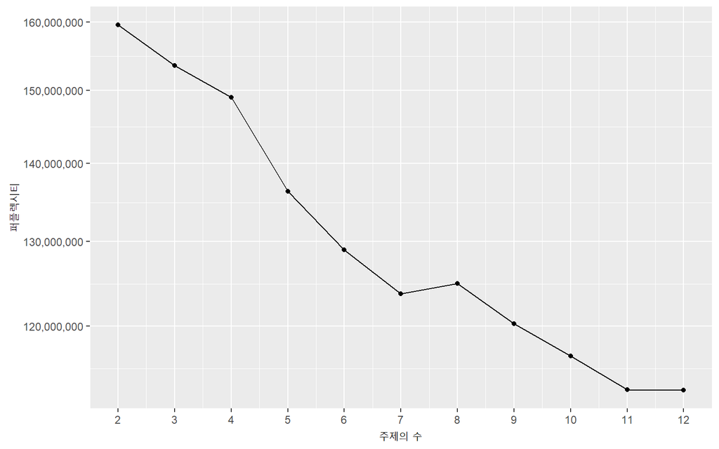

```r
# 주제 수 증가에 따른 퍼플렉시티의 변화 추세 시각화하기.
ppl.per.topic %>%
  ggplot(aes(k, ppl.sum)) + # x축은 주제 수, y축은 퍼플렉시티 합산 점수.
  geom_line() + # 데이터를 선으로 나타내기.
  geom_point() + # 데이터를 점으로 나타내기.
  scale_x_continuous(breaks=c(2,3,4,5,6,7,8,9,10,11,12)) + # x축 팁을 2부터 12까지 1단위로 표기하기.
  scale_y_log10(labels = scales::comma) + # y축 값을 밑을 10으로 취하는 로그 값으로 바꾸기. 이때 지수 표기 금지.
  labs(x = "주제의 수",
       y = "퍼플렉시티")
```

## (3) 부록: TF-IDF

### 1) 단어의 중요도 분석 지수

- 단어 빈도(term frequency, TF)
  - 설명: 해당 단어가 문서에 몇 번 출현하는가?
  - 단점: 불용어의 경우 빈도는 높지만 중요도는 낮음.
- 역문서 빈도(inverse document frequency, IDF)
  - 설명: 문서마다 공통으로 자주 나타나는 단어의 가중치는 줄이고 문서들에 자주 나타나지 않지 않는 단어의 가중치는 높임.
  - 공식
    - DF(*t*): 특정 단어 *t*가 등장한 문서의 수.
    - IDF(*d*, *t*): DF(*t*)에 반비례하는 수.
    - $IDF(단어)=ln(\frac{문서의\: 수}{해당\: 단어가\: 포함된\: 문서의 \:수})$
- 단어 빈도-역문서 빈도(term frequency-inverse document frequency, TF-IDF)
  - 설명
    - 단어가 말뭉치(예를 들면 소설 말뭉치) 내 특정 문서(예를 들면 조세희의 작품)에 얼마나 중요성을 지니는지를 측정하기 위해 고안된 지수.
    - DTM 내 단어마다 중요도를 가중치로 부여.
  - 공식: TF와 IDF의 곱.

### 2) TF-IDF 계산

- `bind_tf_idf` 함수
  - **tidytext** 내장 함수.
  - 입력: tidy 텍스트 데이터셋.
  - 출력
    - `word`: 단어/토큰.
    - 문서: 해당 토큰이 나타난 문서.
    - `n`: 문서 내 토큰의 빈도.
    - `total`: 문서에 나타난 토큰의 총 수.
    - `tf`: $\frac{n}{total}$
    - `idf`.
    - `tf_idf`.

### 3) 실습

- `bind_tf_idf` 함수를 사용하여 네 작품의 TF-IDF 값 구하기

```r
sjnovel.tf_idf <- sjnovel.tokenized %>%
    count(title, word, sort = TRUE) %>% # 작품별로 단어 빈도 분석하기.
    bind_tf_idf(word, title, n) %>% # TF-IDF 값 계산하기.
    arrange(-tf_idf) %>% # TF-IDF 값을 기준으로 내림차순 배열하기.
    group_by(title) %>% # 작품명을 기준으로 grouping하기.
    top_n(10) %>% # 상위 10개 단어 서브세팅하기.
    ungroup()
sjnovel.tf_idf
```

```
## # A tibble: 42 x 6
##    title                     word         n     tf   idf tf_idf
##    <chr>                     <chr>    <int>  <dbl> <dbl>  <dbl>
##  1 광장                      명준       254 0.0258  1.39 0.0358
##  2 난장이가 쏘아올린 작은 공 영희        89 0.0203  1.39 0.0282
##  3 사람의 아들               남         147 0.0146  1.39 0.0202
##  4 사람의 아들               경사__14   146 0.0145  1.39 0.0200
##  5 아랑은 왜                 아랑       235 0.0139  1.39 0.0192
##  6 사람의 아들               아하스     135 0.0134  1.39 0.0185
##  7 사람의 아들               페르츠     130 0.0129  1.39 0.0179
##  8 사람의 아들               민요섭     108 0.0107  1.39 0.0148
##  9 아랑은 왜                 억균       180 0.0106  1.39 0.0147
## 10 아랑은 왜                 영주       174 0.0103  1.39 0.0143
## # ... with 32 more rows
```

- **ggplot2**를 사용하여 TF-IDF 분석 결과 시각화하기

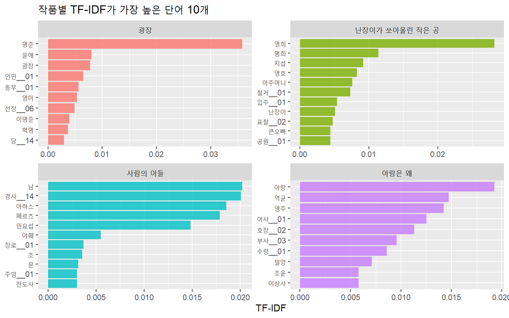

```r
sjnovel.tf_idf %>%
    mutate(word = reorder_within(word, tf_idf, title)) %>% # TF-IDF 내림차순으로 배열되도록 하기.
    ggplot(aes(word, tf_idf, fill = title)) + # x축은 word, y축은 tf-idf, 색상은 title.
    geom_col(alpha = 0.8, show.legend = FALSE) + # 바의 색상 조정. 범례는 제거.
    facet_wrap(~ title, scales = "free", ncol = 2) + # 작품명 기준으로 2열 다면출력.
    scale_x_reordered() + # x축은 reorder된 상태 유지.
    coord_flip() + # x축과 y축 위치 서로 바꾸기.
    theme(strip.text=element_text(size=11)) + # 다면출력 표제 텍스트 크기 지정하기.
    labs(x = NULL, y = "TF-IDF",
         title = "작품별 TF-IDF가 가장 높은 단어 10개")
```

# References

길호현. (2018). 텍스트마이닝을 위한 한국어 불용어 목록 연구. **우리말글**, 78, 1-25.

김문형, 장하연, 조유미, & 신효필. (2013). KOSAC (Korean Sentiment Analysis Corpus): 한국어 감정 및 의견 분석 코퍼스. **한국정보과학회 학술발표논문집**, 650-652.

노성화, 김정. (2022). 텍스트마이닝을 위한 한국어 범용 불용어 목록 연구. **한말연구**, **63**(13), 1-15.

손선주, 박미숙, 박지은, 손진훈. (2012). 한국어 감정표현단어의 추출과 범주화. **감성과학**, **15**(1), 105-120.

안도현. (2022). **R로 하는 텍스트마이닝**. Retrieved September 25, 2022 from https://bookdown.org/ahn_media/bookdown-demo

온병원, 박상민, 나철원. (2018). **KNU 한국어 감성사전.** Retrieved September 25, 2022 from https://github.com/park1200656/KnuSentiLex

Blei, D. M. (2012). Probabilistic topic models. *Communications of the ACM*, *55*(4), 77-84.

Silge, J., & Robinson, D. (2017). *Text mining with R.* Retrieved September 25, 2022 from https://www.tidytextmining.com

Zhang, Z. (2018). *Text mining for social and behavioral research using R: A case study on reaching evaluation.* Retrieved September 31, 2022 from https://books.psychstat.org/textmining/index.html